# BINF620 - Midterm

Manning Smith

11/6/2024

# Import Data

```r
# Part 1
p1Data <- read.csv("BINF620BigData-1.csv")
#View(p1Data)

# Part 2
p2Data <- read.csv("PARMSOct2020.csv")
#View(p2Data)
```

### Data Dictionary | Data Set 1

- PID: Patient ID
- Age: in years
- Gender: F/M, Female/Male
- Ethnicity:
  - HISPANIC OR LATINO
  - NOT HISPANIC OR LA
  - NOT REPORTED
- White:
  - 0: White
  - 1: Non-white
- LVEF: Left ventricular ejection fraction
- A1c: Average amount of glucose (sugar) in blood
- SBP: Systolic blood pressure, mm Hg
- DBP: Diastolic blood pressure, mm Hg
- BMI: Body mass index $\frac{kg}{m^2}$
- Ischemic Status:
  - Ischemic
  - Non-Ischemic
- Reason of End the Study:
  - STUDY TERMINATED BY SPONSOR
  - DEATH
  - LOST TO FOLLOW-UP
  - PHYSICIAN DECISION
  - WITHDEAWAL BY SUBJECT
- Months of Follow-up: In months
- Group:
  - Placebo
  - Triinhibitor
- GFR: Glomerular filtration rate

### Data Dictionary | Data Set 2

- ID: Subject Identifier
- ALIVE: 1–infant alive; 2—infant not alive;
- BF5EVER: Breastfeed–ever, 1=No, 2=Yes.
- BF5LNGTH: duration – length of time in weeks
- PGWT_GN: Pregnant weight gain/lost
- MOM_CM: Moms height – centimeters
- MOM_BMI: MOM BODY MASS INDEX
- MOMCIG: Number of Cigarettes Per Day
- CIG_PRIOR : No. of cigarettes smoked - prior to pregnant
- MOM_LBKG : Moms weight – before pregnant
- DDS_INS DDS: insurance
  - .A = NOT APPLICABLE.B = DK/BLANK
  - .N = NOT RECORDED
  - .U = UNKNOWN
  - 1 = NO
  - 2 = YES
- MH_PPDPR MH: depress since birth
  - .B = BLANK/DK
  - .S = SKIP
  - 1 = ALWAYS
  - 2 = OFTEN/ALMOST ALWAYS
  - 3 = SOMETIMES
  - 4 = RARELY
  - 5 = NEVER

# Part 1

## Introduction

The goal of this project is to examine a dataset that looks at the impact of treating hyperglycemia in patients with diabetes mellitus. Our goal is to conduct survival analysis to examine the impact of Triinhibitor vs placebo on the survival of the patient.

```r
summary(p1Data)
```

```
##       PID              Age           Gender           Ethnicity
##  Min.   :   1.0   Min.   :36.00   Length:1222        Length:1222
##  1st Qu.: 306.2   1st Qu.:63.00   Class :character   Class :character
##  Median : 611.5   Median :70.00   Mode  :character   Mode  :character
##  Mean   : 611.5   Mean   :68.94
##  3rd Qu.: 916.8   3rd Qu.:76.00
##  Max.   :1222.0   Max.   :85.00
##
##      White              LVEF            A1c              SBP
##  Min.   :0.00000   Min.   :10.00   Min.   : 4.500   Min.   : 85.0
##  1st Qu.:0.00000   1st Qu.:28.00   1st Qu.: 6.400   1st Qu.:111.1
##  Median :0.00000   Median :35.00   Median : 7.100   Median :122.0
##  Mean   :0.05868   Mean   :37.46   Mean   : 7.561   Mean   :124.2
##  3rd Qu.:0.00000   3rd Qu.:46.00   3rd Qu.: 8.300   3rd Qu.:134.0
##  Max.   :1.00000   Max.   :79.00   Max.   :15.000   Max.   :193.0
##  NA's   :12        NA's   :2       NA's   :59
##       DBP             BMI       Ischemic.Status    Reason.of.End.the.Study
##  Min.   : 36.5   Min.   :16.8   Length:1222        Length:1222
##  1st Qu.: 65.0   1st Qu.:26.9   Class :character   Class :character
##  Median : 72.0   Median :30.8   Mode  :character   Mode  :character
##  Mean   : 73.0   Mean   :31.2
##  3rd Qu.: 80.0   3rd Qu.:34.5
##  Max.   :120.0   Max.   :74.0
##                  NA's   :3
##  Months.of.Follow.up    Group                GFR
##  Min.   : 0.03282    Length:1222        Min.   : 16.90
##  1st Qu.: 4.98802    Class :character   1st Qu.: 39.80
##  Median : 9.18846    Mode  :character   Median : 49.70
##  Mean   : 9.38332                       Mean   : 53.19
##  3rd Qu.:13.47915                       3rd Qu.: 62.50
##  Max.   :29.00929                       Max.   :146.40
##                                         NA's   :39
```

## Data Exploration

The dataset has 1222 observations, with 15 different variables of interest. Are main focus for this analysis will be the `Group` and `Reason of End the Study`.

Before we can start our analysis there are some data cleaning steps that were performed. There were no transformations of any of the variables, but changes to values of `Gender` was made to turn the values into a numerical. Also, a new variable was made that sorts the death types into a binary variable. 1 = Death and 0 = Survival. This variable will be used for our analysis.

```r
# Clean Raw
p1Data <- p1Data %>% rename(Event_type = `Reason.of.End.the.Study`)
p1Data <- p1Data %>% rename(Time = `Months.of.Follow.up`)

# Filter Data
filtered_p1Data <- p1Data %>%
  filter(Event_type %in% c("DEATH", "STUDY TERMINATED BY SPONSOR"))

p1Data$Event <- ifelse(p1Data$Event_type == "DEATH", 1, 0)
p1Data$Gender <- ifelse(p1Data$Gender == "M", 0,
                      ifelse(p1Data$Gender == "F", 1, NA))
p1Data$Group <- factor(p1Data$Group, levels = c("Placebo", "Triinhibitor"))

filtered_p1Data$Event <- ifelse(filtered_p1Data$Event_type == "DEATH", 1, 0)
filtered_p1Data$Gender <- ifelse(filtered_p1Data$Gender == "M", 0,
                      ifelse(filtered_p1Data$Gender == "F", 1, NA))
filtered_p1Data$Group <- factor(filtered_p1Data$Group, levels = c("Placebo", "Triinhibitor"))
```

We will start by understanding some basic associations in our data to see if we can gain some prior knowledge before jumping into a complex model. First see the distribution of `Gender` in our dataset side by side with the distribution of `Age`.

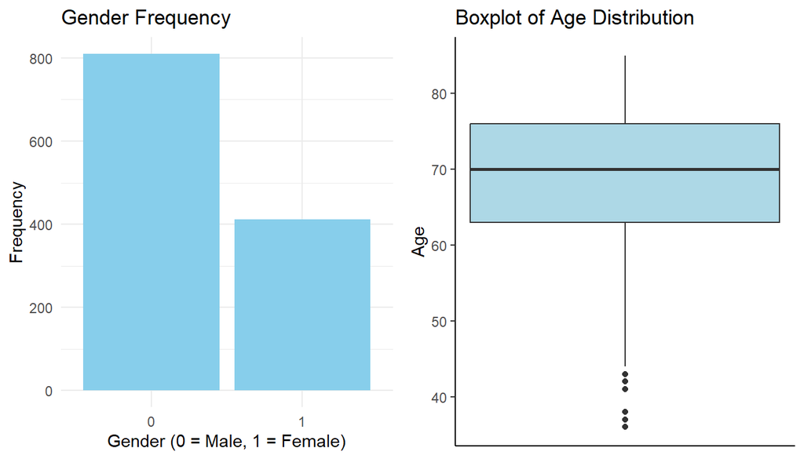

```r
genFreq <- ggplot(p1Data, aes(x = as.factor(Gender))) +
  geom_bar(fill = "skyblue") +
  labs(x = "Gender (0 = Male, 1 = Female)", y = "Frequency", title = "Gender Frequency") +
  theme_minimal()

ageDis <- ggplot(p1Data, aes(y = Age)) +
  geom_boxplot(fill = "lightblue") +
  labs(y = "Age", title = "Boxplot of Age Distribution") +
  theme_classic() +
  theme(axis.title.x = element_blank(),
        axis.text.x = element_blank(),
        axis.ticks.x = element_blank())

grid.arrange(genFreq, ageDis, ncol = 2, nrow = 1)
```

Next we will explore the distribution of our `Event` variable. See the difference between our binary variable for death vs the original forms of survival.

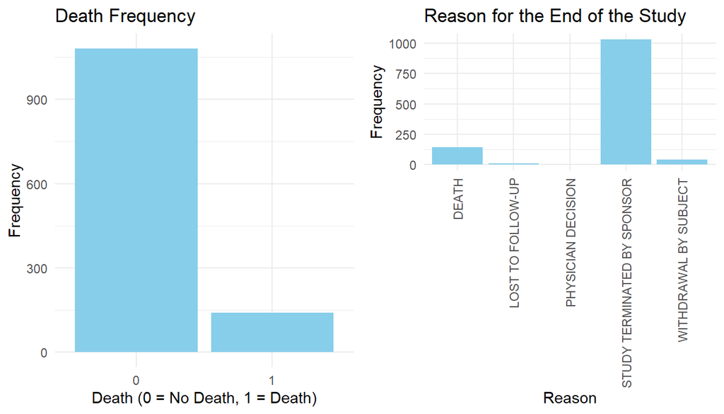

```r
deathFreq <- ggplot(p1Data, aes(x = as.factor(Event))) +
  geom_bar(fill = "skyblue") +
  labs(x = "Death (0 = No Death, 1 = Death)", y = "Frequency", title = "Death Frequency") +
  theme_minimal()

studyEnd <- ggplot(p1Data, aes(x = as.factor(Event_type))) +
  geom_bar(fill = "skyblue") +
  labs(x = "Reason", y = "Frequency", title = "Reason for the End of the Study") +
  theme_minimal() +
  theme(axis.text.x = element_text(angle = 90, vjust = 0.5, hjust = 1))

grid.arrange(deathFreq, studyEnd, ncol = 2, nrow = 1)
```

For the sake of this research, we will filter out all the reasons for end of study other than “Death” and “Terminated by Sponsor”. We will use this Binary form of event type for our analysis purposes. This is important to remember when we make our conclusions that we can not generalize to all, but only to the types of responses we have filtered for.

See our filtered data below:

```r
# Filter Data
filtered_p1Data <- p1Data %>%
  filter(Event_type %in% c("DEATH", "STUDY TERMINATED BY SPONSOR"))

filtered_p1Data$Event <- ifelse(filtered_p1Data$Event_type == "DEATH", 1, 0)
filtered_p1Data$Gender <- ifelse(filtered_p1Data$Gender == "M", 0,
                      ifelse(filtered_p1Data$Gender == "F", 1, NA))
```

There is nothing crazy that sticks out to us when looking at the shape of some of our data points. We shall proceed with the survival analysis methods.

## Analysis

To start we will utilize the Kaplan-Meier method on both our original data and our filtered data. Please see the model utilized: `Surv(Time, Event) ~ Group`. The top plot is the unfiltered data and the bottom is the filtered data.

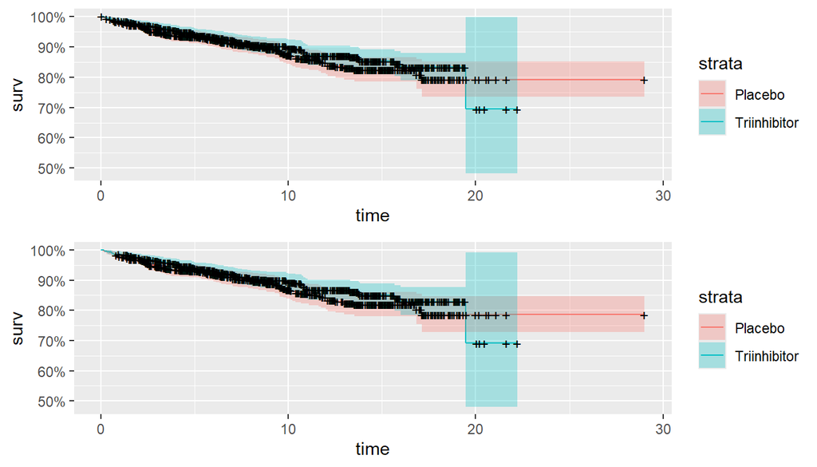

```r
### Kaplan–Meier method
km_fit <- survfit(Surv(Time, Event) ~ Group, data=p1Data)
p1 <- autoplot(km_fit)

# Filtered
km_fit_fil <- survfit(Surv(Time, Event) ~ Group, data=filtered_p1Data)
p2 <- autoplot(km_fit_fil)

grid.arrange(p1, p2, ncol = 1, nrow = 2)
```

```r
# Results for Filtered Kaplan-Meier Analysis
km_fit_fil
```

```
## Call: survfit(formula = Surv(Time, Event) ~ Group, data = filtered_p1Data)
##
##                      n events median 0.95LCL 0.95UCL
## Group=Placebo      585     76     NA      NA      NA
## Group=Triinhibitor 587     65     NA    19.5      NA
```

Notice that there was no significant different between the filtered data and the original data, thus we will use the filtered data moving forward.

```r
### Cox
cox_fit <- coxph(Surv(Time, Event) ~ Group + Age + Gender + Ethnicity + White +
                 LVEF + A1c + SBP + DBP + BMI + Ischemic.Status + GFR, data = filtered_p1Data)

### Hazard
haz_ratio <- exp(coef(cox_fit))  # Hazard Ratios
haz_ratioINT <- exp(confint(cox_fit))  # 95% CI for Hazard Ratios

# Schoenfeld residuals test for proportional hazards assumption
ph_test <- cox.zph(cox_fit)
```

We will look at the Cox Regression analysis and confirm our assumptions by looking at the proportional hazards.

## Results

```r
# View Results
summary(cox_fit)
```

```
## Call:
## coxph(formula = Surv(Time, Event) ~ Group + Age + Gender + Ethnicity +
##     White + LVEF + A1c + SBP + DBP + BMI + Ischemic.Status +
##     GFR, data = filtered_p1Data)
##
##   n= 1089, number of events= 126
##    (83 observations deleted due to missingness)
##
##                                  coef exp(coef)  se(coef)      z Pr(>|z|)
## GroupTriinhibitor           -0.234535  0.790938  0.181438 -1.293   0.1961
## Age                          0.020536  1.020748  0.011797  1.741   0.0817 .
## Gender                      -0.345099  0.708151  0.212395 -1.625   0.1042
## EthnicityNOT HISPANIC OR LA  0.097397  1.102298  0.212239  0.459   0.6463
## EthnicityNOT REPORTED        0.924566  2.520775  1.032356  0.896   0.3705
## White                       -0.069478  0.932881  0.432559 -0.161   0.8724
## LVEF                        -0.005377  0.994637  0.007986 -0.673   0.5007
## A1c                          0.034105  1.034693  0.058046  0.588   0.5568
## SBP                         -0.011266  0.988797  0.006557 -1.718   0.0858 .
## DBP                          0.007668  1.007697  0.008079  0.949   0.3426
## BMI                         -0.015718  0.984405  0.016699 -0.941   0.3466
## Ischemic.StatusIschemic     -0.686500  0.503335  1.013700 -0.677   0.4983
## Ischemic.StatusNon-ischemic -0.639377  0.527621  1.017460 -0.628   0.5297
## GFR                         -0.004305  0.995705  0.005238 -0.822   0.4112
## ---
## Signif. codes:  0 '***' 0.001 '**' 0.01 '*' 0.05 '.' 0.1 ' ' 1
##
##                             exp(coef) exp(-coef) lower .95 upper .95
## GroupTriinhibitor              0.7909     1.2643   0.55425     1.129
## Age                            1.0207     0.9797   0.99742     1.045
## Gender                         0.7082     1.4121   0.46702     1.074
## EthnicityNOT HISPANIC OR LA    1.1023     0.9072   0.72718     1.671
## EthnicityNOT REPORTED          2.5208     0.3967   0.33327    19.067
## White                          0.9329     1.0719   0.39961     2.178
## LVEF                           0.9946     1.0054   0.97919     1.010
## A1c                            1.0347     0.9665   0.92343     1.159
## SBP                            0.9888     1.0113   0.97617     1.002
## DBP                            1.0077     0.9924   0.99187     1.024
## BMI                            0.9844     1.0158   0.95271     1.017
## Ischemic.StatusIschemic        0.5033     1.9868   0.06902     3.670
## Ischemic.StatusNon-ischemic    0.5276     1.8953   0.07182     3.876
## GFR                            0.9957     1.0043   0.98553     1.006
##
## Concordance= 0.615  (se = 0.028 )
## Likelihood ratio test= 17.71  on 14 df,   p=0.2
## Wald test            = 17.79  on 14 df,   p=0.2
## Score (logrank) test = 17.99  on 14 df,   p=0.2
```

```r
ph_test
```

```
##                  chisq df     p
## Group            0.789  1 0.374
## Age              1.227  1 0.268
## Gender           1.364  1 0.243
## Ethnicity        6.848  2 0.033
## White            1.257  1 0.262
## LVEF             0.124  1 0.725
## A1c              0.136  1 0.713
## SBP              0.290  1 0.590
## DBP              2.619  1 0.106
## BMI              0.404  1 0.525
## Ischemic.Status  1.581  2 0.454
## GFR              0.277  1 0.599
## GLOBAL          16.562 14 0.280
```

From the Cox Regression we can see that the analysis was made on 1089 observations after the removal of 83 entries due to missing values. None of the predictors in the model suggested significant evidence with a confidence of 95%. However, two predictors suggested am impact with a confidence of 90%. These would be `Age` and `SBP`.

`Age`: p-value: $0.082$  
`SBP`: p-value: $0.086$

These predictors both suggest that with 90% confidence there is an associated between them and the survival. This is expected for age, as the age of a patient increases there survival time is expected to decreases, this can be explained by normal factors. In the case of Systolic blood pressure, there could be an association be a higher systolic blood pressure and the survival time of a patient. However, for our purposes neither of these are helpful predictors in association between the treatment and placebo.

There was no evidence of any significance between the association of treatment vs placebo. There was a 21% reduction in hazard of death between the treatment and placebo with a significance of $0.196$, thus suggesting there is no enough evidence to suggest an improvement on the survival time of the patient.

### Conclusion

Due to the lack of evidence in the results from both the Kaplan–Meier Method and the Cox Regression there is not enough evidence to suggest that a treatment as an improvement on the Survival Time of a patient.

In conclusion, the Triinhibitor treatment does not show a significant effect on survival, and none of the other predictors reach strong significance. This evidence also suggests that no further exploration of a different model approach may be warranted to clarify these relationships.

# Part 2

## Introduction

The goal of this section is examine some data points form the Pregnancy Risk Assessment Monitoring System, provided by the CDC. These data include about 83% of all us births and associated data points. Out goal is to perform some analysis around the `MH_PPDPR` variable, depress since birth. The goal is to determine any association between the predictors and the `MH_PPDPR` variable.

The model utilized in these analysis is comprised of the following variables:

**Response Variable:** `MH_PPDPR`  
**Predictor Variables:** `PGWT_GN, MOM_CM, MOM_BMI, MOMCIG , CIG_PRIOR , MOM_LBKG`, and `DDS_INS`  
**Model:** `MH_PPDPR ~ PGWT_GN + MOM_CM + MOM_BMI + MOMCIG + CIG_PRIOR + MOM_LBKG + DDS_INS`

We will utilize different techniques such as Naive Bayes, lad, qda, k-nearest neighbors. All these methods will utilize the variables discussed above.

```r
summary(p2Data)
```

```
##       ID                MOMCIG          MOM_LBKG        BF5EVER
##  Length:340357      Min.   : 0.000   Min.   :  2.0   Min.   :1.000
##  Class :character   1st Qu.: 0.000   1st Qu.:125.0   1st Qu.:2.000
##  Mode  :character   Median : 0.000   Median :145.0   Median :2.000
##                     Mean   : 0.902   Mean   :152.6   Mean   :1.852
##                     3rd Qu.: 0.000   3rd Qu.:174.0   3rd Qu.:2.000
##                     Max.   :98.000   Max.   :466.0   Max.   :2.000
##                     NA's   :10776    NA's   :6684    NA's   :11970
##     BF5LNGTH         MOM_BMI           ALIVE         CIG_PRIOR
##  Min.   : 1.00    Min.   :  0.35   Min.   :1.00    Min.   : 0.00
##  1st Qu.: 2.00    1st Qu.: 21.63   1st Qu.:1.00    1st Qu.: 0.00
##  Median : 3.00    Median : 24.69   Median :1.00    Median : 0.00
##  Mean   : 7.15    Mean   : 26.31   Mean   :1.01    Mean   : 1.68
##  3rd Qu.: 6.00    3rd Qu.: 29.38   3rd Qu.:1.00    3rd Qu.: 0.00
##  Max.   :41.00    Max.   :116.05   Max.   :2.00    Max.   :98.00
##  NA's   :220464   NA's   :16539    NA's   :68807   NA's   :75937
##      MOM_CM          DDS_INS          PGWT_GN          MH_PPDPR
##  Min.   :104      Min.   :1.00     Min.   :  0.00   Min.   :1
##  1st Qu.:157      1st Qu.:1.00     1st Qu.: 20.00   1st Qu.:3
##  Median :163      Median :2.00     Median : 30.00   Median :4
##  Mean   :163      Mean   :1.74     Mean   : 31.01   Mean   :4
##  3rd Qu.:168      3rd Qu.:2.00     3rd Qu.: 40.00   3rd Qu.:5
##  Max.   :410      Max.   :2.00     Max.   :323.00   Max.   :5
##  NA's   :125030   NA's   :148413   NA's   :204879   NA's   :122239
```

## Data Exploration | Raw Data

We will start by looking as the structure of the data. The dataset is comprised of over 340,000 observations with 12 different variables. We have selected 8 variables of interest.

### Data Structure

```r
str(p2Data)
```

```
## 'data.frame':    340357 obs. of  12 variables:
##  $ ID       : chr  "2009OK270001" "2009OK270003" "2009OK270004" "2009OK270006" ...
##  $ MOMCIG   : int  0 0 0 0 0 0 0 10 0 0 ...
##  $ MOM_LBKG : int  255 150 157 145 125 165 160 115 300 NA ...
##  $ BF5EVER  : int  2 2 2 2 2 NA NA 2 2 NA ...
##  $ BF5LNGTH : int  6 NA 3 2 3 NA NA 3 1 NA ...
##  $ MOM_BMI  : num  46.6 22.1 26.1 26.5 19.6 ...
##  $ ALIVE    : int  NA NA NA NA NA NA NA NA NA NA ...
##  $ CIG_PRIOR: int  NA NA NA NA NA NA NA NA NA NA ...
##  $ MOM_CM   : int  NA NA NA NA NA NA NA NA NA NA ...
##  $ DDS_INS  : int  NA NA NA NA NA NA NA NA NA NA ...
##  $ PGWT_GN  : int  NA NA NA NA NA NA NA NA NA NA ...
##  $ MH_PPDPR : int  NA NA NA NA NA NA NA NA NA NA ...
```

- MH_PPDPR: Depress since birth. This variable will be our response variable. It is a categorical variable represented as integers.
  - .B = BLANK/DK
  - .S = SKIP
  - 1 = ALWAYS
  - 2 = OFTEN/ALMOST ALWAYS
  - 3 = SOMETIMES
  - 4 = RARELY
  - 5 = NEVER

For our purposes we will group this variable into a binary variable.

The first, we will purpose that groups 1 and 2 can be combined into ‘Depressed’ and groups 4,5 can be combined into ‘Not Depressed’; in this analysis we will ignore instances where 3 was reported.

The second, we will purpose that groups 1, 2, and 3 combined into ‘Depressed’ and groups 4,5 can be combined into ‘Not Depressed’.

Lastly, we will purpose that groups 1 is ‘Depressed’ and 5 is ‘Not Depressed’; in this analysis we will ignore instances where 2,3,4 are reported.

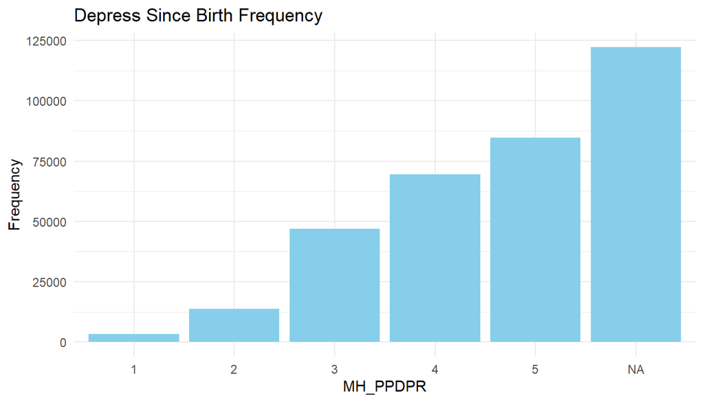

```r
ggplot(p2Data, aes(x = as.factor(MH_PPDPR))) +
  geom_bar(fill = "skyblue") +
  labs(x = "MH_PPDPR", y = "Frequency", title = "Depress Since Birth Frequency") +
  theme_minimal()
```

Notice there are over 100,000 results with missing information. We will use a method to impute this data and use the imputed data set for our analysis.

**Predictors:**  
- PGWT_GN: Pregnant Eight gain/lost. This is a numerical variable that is centered at 30.

- MOM_CM: Moms height in centimeters. This is a numerical variable that is centered at 163cm.
- MOM_BMI: Mom Body Mass Index. This is a numerical variable that is centered at 26.31
- MOMCIG: Number of Cigarettes per day: This is a numerical variable that is centered at .9, but has a max of 98.
- CIG_PRIOR: Number of Total cigarettes smoked prior to pregnant. This is a numerical variable that is centered at 1.68.
- MOM_LBKG: Mom’s weight. This is a numerical variable centered at 152.
- DDS_INS: Insurance. This variable is categorical
  - .A = NOT APPLICABLE.B = DK/BLANK
  - .N = NOT RECORDED
  - .U = UNKNOWN
  - 1 = NO
  - 2 = YES

For our purposes we will filter this data into a binary variable being 1 for no insurance and 2 for insurance.

### Explore Predictor Distributions

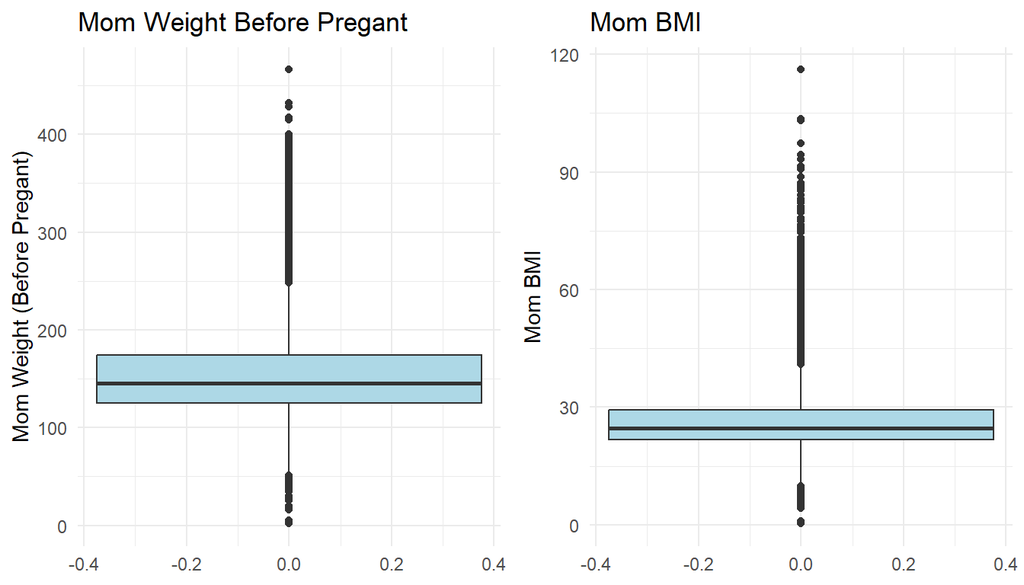

```r
p1 <- ggplot(p2Data, aes(x = as.factor(ALIVE))) +
  geom_bar(fill = "skyblue") +
  labs(x = "Alive (1 = Alive, 2 = Dead)", y = "Frequency", title = "Alive Frequency") +
  theme_minimal()

p2 <- ggplot(p2Data, aes(y = MOM_LBKG)) +
  geom_boxplot(fill = "lightblue") +
  labs(y = "Mom Weight (Before Pregant)", title = "Mom Weight Before Pregant") +
  theme_minimal()

p3 <- ggplot(p2Data, aes(y = MOM_BMI)) +
  geom_boxplot(fill = "lightblue") +
  labs(y = "Mom BMI", title = "Mom BMI") +
  theme_minimal()

p4 <- ggplot(p2Data, aes(y = CIG_PRIOR)) +
  geom_boxplot(fill = "lightblue") +
  labs(y = "Cigarettes Smoked", title = "Cigarettes Smoked Before Pregant") +
  theme_minimal()


grid.arrange(p2, p3, ncol = 2, nrow = 1)
```

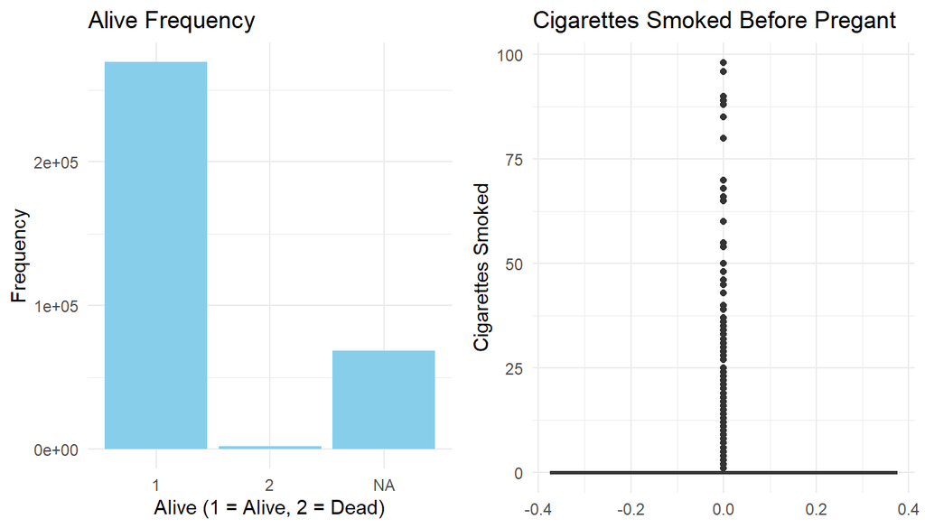

```r
grid.arrange(p1, p4, ncol = 2, nrow = 1)
```

### Zero Variance

```r
nzv <- nearZeroVar(p2Data, saveMetrics = TRUE)
nzv_vars <- rownames(nzv[nzv$nzv == TRUE, ])
```

### Correlation Matrix

Next we will examine the correlation Matrix of our co-variates.

```r
# Calculate and visualize the correlation matrix
cor_matrix <- cor(p2Data %>% select_if(is.numeric), use = "complete.obs")  # selecting numeric vars only
```

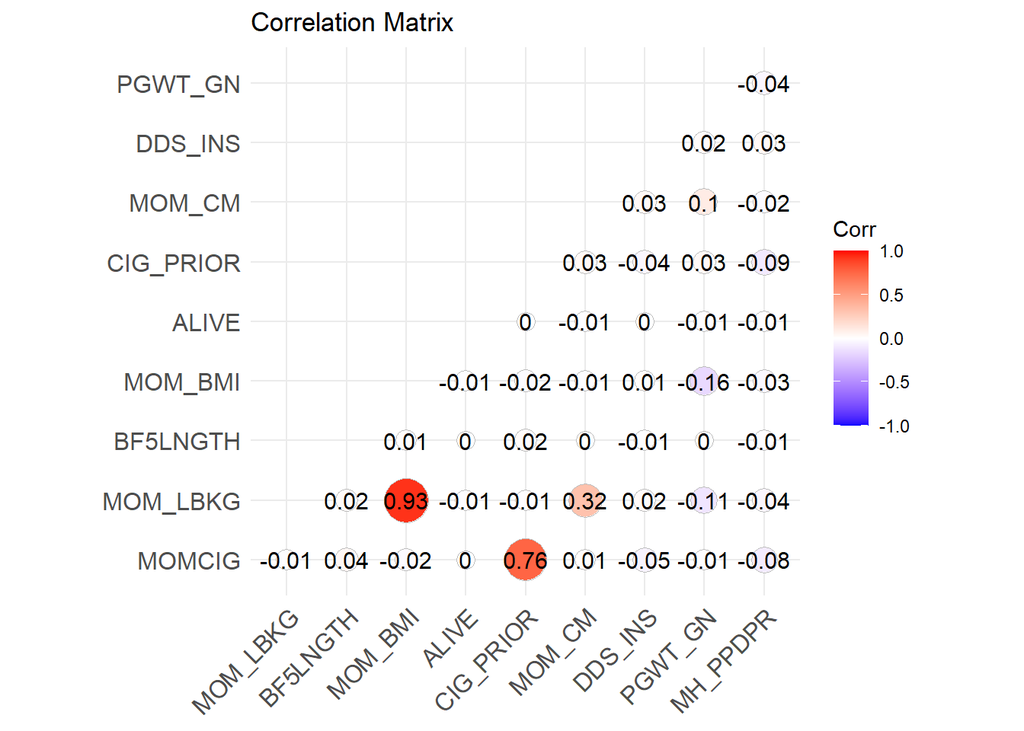

```r
# Visualize correlation matrix
ggcorrplot(cor_matrix, method = "circle", type = "lower", lab = TRUE, title = "Correlation Matrix")
```

Initially, we can see some strong correlations between some variables.

**Strong Correlation:**  
- `MOM_BMI ~ MOM_LBKG` This correlation makes sense as these two variables are related to each other. Thus this can be ignored.

- `MOMCIG ~ CIGPRIOR` This correlation also makes sense as these two variables are related as expected. Thus this can be ignored.

**Moderate Correlation:**  
- `MOM_LBKG ~ MOM_CM` This correlation makes sens with human anatomy as weight height increases so does weight. Thus this can be ignored.

One thing to note is that there is no evidence of an association with our intended response variables and any of the co-varaiates. This is okay, there is nothing to concerning that would keep us from proceeding. It is also worth noting that this is limited interdependence amount are variables, thus further contributing to allowing us to continue.

### Missing-ness

```r
total_rows <- nrow(p2Data)
sumCC <- sum(complete.cases(p2Data))
perct_missing <- (total_rows - sumCC) / total_rows * 100

md_pattern <- md.pattern(p2Data[, -1], plot=FALSE, rotate.names = TRUE)
```

*Total Rows:* 340357  
*Percent Missing:* 89.356

We have a numerous amount of missing variables. We will deal with this via imputing.

The biggest variable with missing values as no impact on our analysis as we are not including this variable into our model.

- `MH_PPDPR` has about 40% missing values, we will impute information for this variable for our analysis.
- `ALIVE` has about 20% missing values, we will impute information for this variable for our analysis.

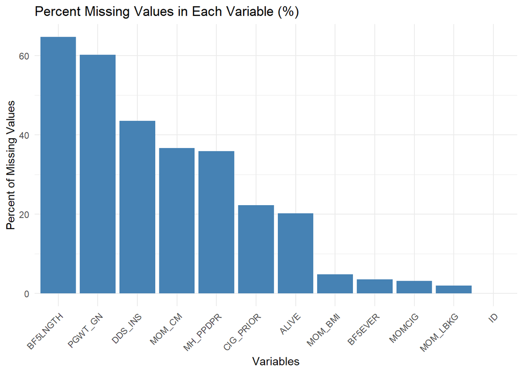

### Imputed Data

These data was imputed by the following code, but for speed when saving this file, the imputed file was saved a loaded below.

```r
p2_imputed <- mice(p2Data, m=5, method = 'pmm' , maxit=5)
p2_complete <- complete(p2_imputed, 1)
```

## Data Exploration | Imputed Data

### Distribution of Drepression Since Birth

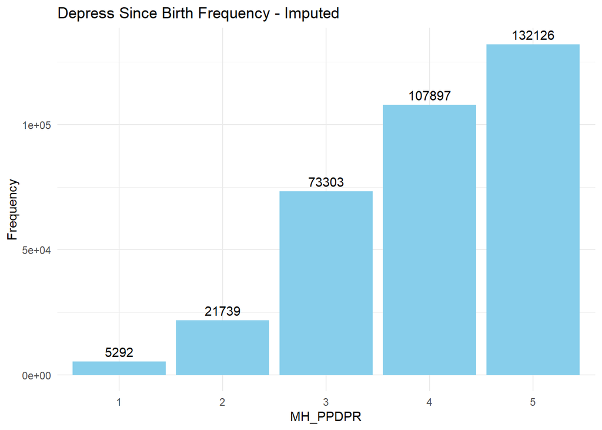

```r
ggplot(p2_complete, aes(x = as.factor(MH_PPDPR))) +
  geom_bar(fill = "skyblue") +
  geom_text(stat = "count", aes(label = after_stat(count)), vjust = -0.5) +
  labs(x = "MH_PPDPR", y = "Frequency", title = "Depress Since Birth Frequency - Imputed") +
  theme_minimal()
```

With the imputed dataset we will follow the same bucketing guidelines discussed above in the data exploration section. These principles will allows us to narrow in on an effective analysis.

### Correlation Matrix

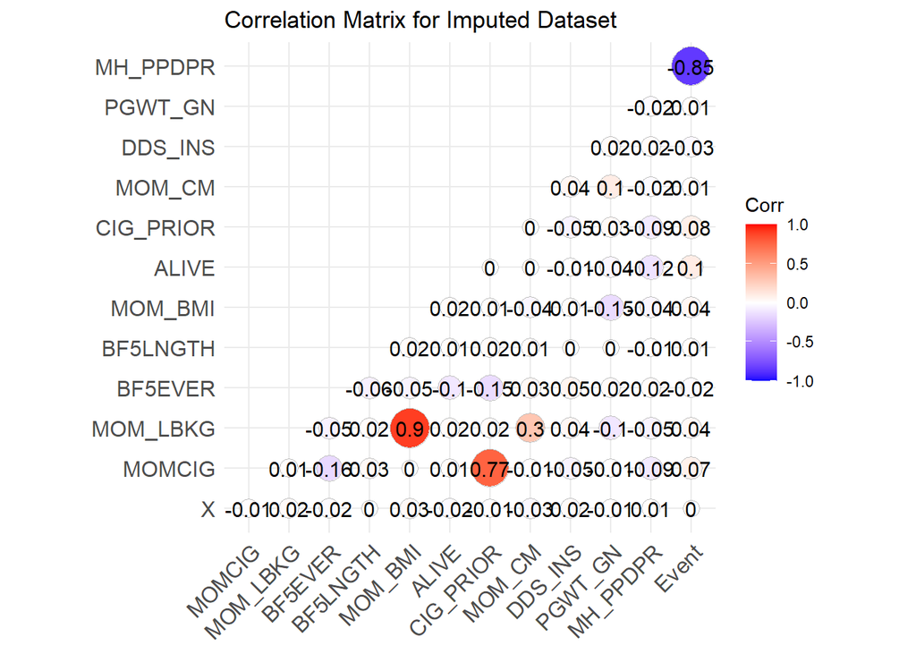

```r
# Calculate and visualize the correlation matrix
cor_matrix <- cor(p2_complete %>% select_if(is.numeric), use = "complete.obs")  # selecting numeric vars only

# Visualize correlation matrix
ggcorrplot(cor_matrix, method = "circle", type = "lower", lab = TRUE, title = "Correlation Matrix for Imputed Dataset")
```

Notice that there is no significant different in the correlation matrix of our imputed dataset compared to the original. Thus we will continue with the same assumptions satisfied.

### Create Binary Variable

As previously stated, we are going to turn our response variable into a binary variable and split into 3 diffent specs.

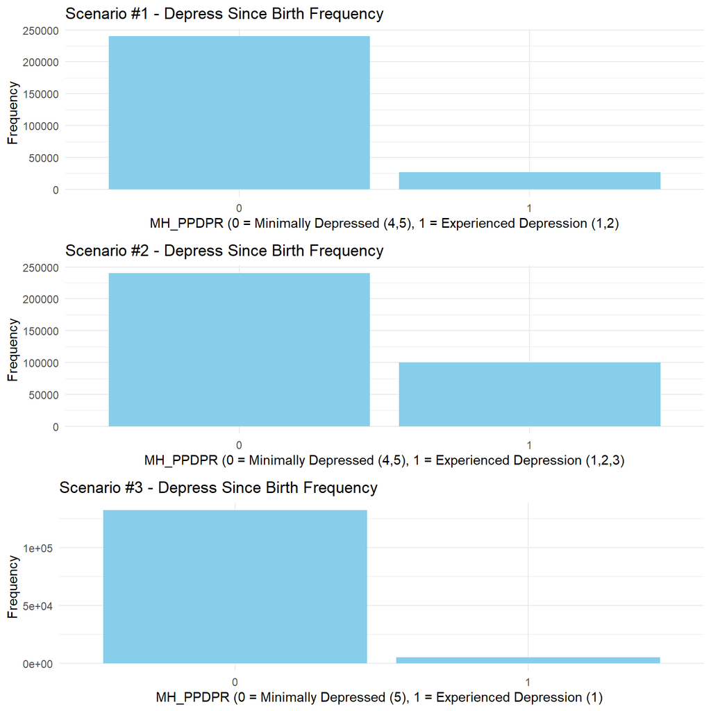

```r
# Scenario 1
scen1_p2Data <- p2_complete %>%
  filter(MH_PPDPR %in% c(1,2,4,5))

scen1_p2Data$Event <- ifelse(scen1_p2Data$MH_PPDPR %in% c(1, 2), 1, 0)

sP1 <- ggplot(scen1_p2Data, aes(x = as.factor(Event))) +
  geom_bar(fill = "skyblue") +
  labs(x = "MH_PPDPR (0 = Minimally Depressed (4,5), 1 = Experienced Depression (1,2)", y = "Frequency", title = "Scenario #1 - Depress Since Birth Frequency") +
  theme_minimal()

# Scenario 2
scen2_p2Data <- p2_complete

scen2_p2Data$Event <- ifelse(p2_complete$MH_PPDPR %in% c(1, 2, 3), 1, 0)

sP2 <- ggplot(scen2_p2Data, aes(x = as.factor(Event))) +
  geom_bar(fill = "skyblue") +
  labs(x = "MH_PPDPR (0 = Minimally Depressed (4,5), 1 = Experienced Depression (1,2,3)", y = "Frequency", title = "Scenario #2 - Depress Since Birth Frequency") +
  theme_minimal()

# Scenario 3
scen3_p2Data <- p2_complete %>%
  filter(MH_PPDPR %in% c(1,5))

scen3_p2Data$Event <- ifelse(scen3_p2Data$MH_PPDPR %in% 1, 1, 0)

sP3 <- ggplot(scen3_p2Data, aes(x = as.factor(Event))) +
  geom_bar(fill = "skyblue") +
  labs(x = "MH_PPDPR (0 = Minimally Depressed (5), 1 = Experienced Depression (1) ", y = "Frequency", title = "Scenario #3 - Depress Since Birth Frequency") +
  theme_minimal()

grid.arrange(sP1, sP2, sP3, ncol = 1, nrow = 3)
```

See that we have split the 3 different scenarios and will perform the logistic regression on all three scenarios and then we will decide which scenario to peruse in further analysis. Note that in scenario 3 the number of observations that experienced depression is significantly less than the other scenarios. Scenario 2 has the most observations for experienced depression. We are suggesting the our best results will come from scenario 1 as it is appropriate that we ignore the middle category and focus on the extremes. However, it is expected the the suggests evidence will come from scenario 3, but this scenario has much more missing data than the others.

## Analysis

### Train / Test Set

```r
# Factor Variable
scen1_p2Data$Event <- as.factor(scen1_p2Data$Event)

trainIndex <- createDataPartition(scen1_p2Data$Event, p = 0.8, list = FALSE)

spec1_trainData <- scen1_p2Data[trainIndex, ]
spec1_testData <- scen1_p2Data[-trainIndex, ]

spec1_trainData$Event <- as.factor(spec1_trainData$Event)
```

```r
# Factor Variable
scen2_p2Data$Event <- as.factor(scen2_p2Data$Event)

trainIndex <- createDataPartition(scen2_p2Data$Event, p = 0.8, list = FALSE)

spec2_trainData <- scen2_p2Data[trainIndex, ]
spec2_testData <- scen2_p2Data[-trainIndex, ]

spec2_trainData$Event <- as.factor(spec2_trainData$Event)
```

```r
# Factor Variable
scen3_p2Data$Event <- as.factor(scen3_p2Data$Event)

trainIndex <- createDataPartition(scen3_p2Data$Event, p = 0.8, list = FALSE)

spec3_trainData <- scen3_p2Data[trainIndex, ]
spec3_testData <- scen3_p2Data[-trainIndex, ]

spec3_trainData$Event <- as.factor(spec3_trainData$Event)
```

```r
# Factor Variable
p2_complete$Event <- as.factor(p2_complete$Event)

trainIndex <- createDataPartition(p2_complete$Event, p = 0.8, list = FALSE)

p2_trainData <- p2_complete[trainIndex, ]
p2_testData <- p2_complete[-trainIndex, ]

p2_trainData$Event <- as.factor(p2_trainData$Event)
```

### Logistic Regression

```r
# Spec 1
logit_spec1 <- train(Event ~ PGWT_GN + MOM_CM + MOM_BMI + MOMCIG + CIG_PRIOR + MOM_LBKG + DDS_INS,
                     data = spec1_trainData, method = "glm", family = binomial)
logit_spec1
```

```
## Generalized Linear Model
##
## 213644 samples
##      7 predictor
##      2 classes: '0', '1'
##
## No pre-processing
## Resampling: Bootstrapped (25 reps)
## Summary of sample sizes: 213644, 213644, 213644, 213644, 213644, 213644, ...
## Resampling results:
##
##   Accuracy   Kappa
##   0.8982694  0.003070393
```

```r
# Spec 2
logit_spec2 <- train(Event ~ PGWT_GN + MOM_CM + MOM_BMI + MOMCIG + CIG_PRIOR + MOM_LBKG + DDS_INS,
                     data = spec2_trainData, method = "glm", family = binomial)
logit_spec2
```

```
## Generalized Linear Model
##
## 272287 samples
##      7 predictor
##      2 classes: '0', '1'
##
## No pre-processing
## Resampling: Bootstrapped (25 reps)
## Summary of sample sizes: 272287, 272287, 272287, 272287, 272287, 272287, ...
## Resampling results:
##
##   Accuracy   Kappa
##   0.7046437  0.005216192
```

```r
# Spec 3
logit_spec3 <- train(Event ~ PGWT_GN + MOM_CM + MOM_BMI + MOMCIG + CIG_PRIOR + MOM_LBKG + DDS_INS,
                     data = spec3_trainData, method = "glm", family = binomial)
logit_spec3
```

```
## Generalized Linear Model
##
## 109935 samples
##      7 predictor
##      2 classes: '0', '1'
##
## No pre-processing
## Resampling: Bootstrapped (25 reps)
## Summary of sample sizes: 109935, 109935, 109935, 109935, 109935, 109935, ...
## Resampling results:
##
##   Accuracy   Kappa
##   0.9610902  0.003384762
```

Notice that from the logistic regression the results align with that of what we expected. Scenario 3 shows the strongest strength in accuracy followed by scenario 1 and then scenario 2. All of the sample sizes are large enough in the scenario and thus allows us to continue with further analysis.

We continue with scenario 1 and 2 and ignore scenario 3 as this may be an overfit.

### Naive Bayes

```r
# Spec 1
spec1_naive <- naive_bayes(as.factor(Event) ~ PGWT_GN + MOM_CM + MOM_BMI + MOM_LBKG, data = spec1_trainData)
summary(spec1_naive)
```

```
##
## ================================= Naive Bayes ==================================
##
## - Call: naive_bayes.formula(formula = as.factor(Event) ~ PGWT_GN + MOM_CM +      MOM_BMI + MOM_LBKG, data = spec1_trainData)
## - Laplace: 0
## - Classes: 2
## - Samples: 213644
## - Features: 4
## - Conditional distributions:
##     - Gaussian: 4
## - Prior probabilities:
##     - 0: 0.8988
##     - 1: 0.1012
##
## --------------------------------------------------------------------------------
```

```r
# Spec 2
spec2_naive <- naive_bayes(as.factor(Event) ~ PGWT_GN + MOM_CM + MOM_BMI + MOM_LBKG, data = spec2_trainData)
summary(spec2_naive)
```

```
##
## ================================= Naive Bayes ==================================
##
## - Call: naive_bayes.formula(formula = as.factor(Event) ~ PGWT_GN + MOM_CM +      MOM_BMI + MOM_LBKG, data = spec2_trainData)
## - Laplace: 0
## - Classes: 2
## - Samples: 272287
## - Features: 4
## - Conditional distributions:
##     - Gaussian: 4
## - Prior probabilities:
##     - 0: 0.7052
##     - 1: 0.2948
##
## --------------------------------------------------------------------------------
```

The results of the Naive Bayes test align with that of the logistic regression. However, there still seems to be some over fitting that is resulting in possible biases in our model. This is something we will consider moving forward in the lda and qda models.

### lda & qda

```r
# lda
spec1_lda = lda(as.factor(Event) ~ PGWT_GN + MOM_CM + MOM_BMI + MOMCIG + CIG_PRIOR + MOM_LBKG + DDS_INS, data = spec1_trainData)
spec1_lda
```

```
## Call:
## lda(as.factor(Event) ~ PGWT_GN + MOM_CM + MOM_BMI + MOMCIG +
##     CIG_PRIOR + MOM_LBKG + DDS_INS, data = spec1_trainData)
##
## Prior probabilities of groups:
##         0         1
## 0.8987802 0.1012198
##
## Group means:
##    PGWT_GN   MOM_CM  MOM_BMI    MOMCIG CIG_PRIOR MOM_LBKG  DDS_INS
## 0 30.71985 163.0213 26.06368 0.7342294  1.450153 151.4261 1.749072
## 1 31.49272 163.1974 27.18523 1.9335029  3.469965 159.0312 1.707098
##
## Coefficients of linear discriminants:
##                    LD1
## PGWT_GN    0.008086129
## MOM_CM    -0.009894966
## MOM_BMI    0.006166522
## MOMCIG     0.126029392
## CIG_PRIOR  0.088581207
## MOM_LBKG   0.009894928
## DDS_INS   -0.445365997
```

```r
spec2_lda = lda(as.factor(MH_PPDPR) ~ PGWT_GN + MOM_CM + MOM_BMI + MOMCIG + CIG_PRIOR + MOM_LBKG + DDS_INS, data = spec2_trainData)
spec2_lda
```

```
## Call:
## lda(as.factor(MH_PPDPR) ~ PGWT_GN + MOM_CM + MOM_BMI + MOMCIG +
##     CIG_PRIOR + MOM_LBKG + DDS_INS, data = spec2_trainData)
##
## Prior probabilities of groups:
##          1          2          3          4          5
## 0.01543959 0.06381502 0.21553728 0.31706251 0.38814560
##
## Group means:
##    PGWT_GN   MOM_CM  MOM_BMI    MOMCIG CIG_PRIOR MOM_LBKG  DDS_INS
## 1 31.10466 162.6694 27.42342 2.4167460  4.153425 159.7314 1.685775
## 2 31.54477 163.2934 27.17029 1.7855087  3.318082 158.9851 1.710290
## 3 31.04149 163.1013 26.44613 1.0708322  2.059706 153.9660 1.729894
## 4 31.14921 163.3566 26.06737 0.7868345  1.570113 152.3050 1.753568
## 5 30.34704 162.7587 26.05502 0.6946360  1.358379 150.7243 1.746298
##
## Coefficients of linear discriminants:
##                    LD1         LD2          LD3         LD4
## PGWT_GN    0.009231283 -0.01837238  0.008420525  0.01764918
## MOM_CM    -0.006755204 -0.06783193  0.095188273 -0.04207243
## MOM_BMI    0.008700648  0.13308975  0.305235835 -0.18603577
## MOMCIG     0.108185862  0.07273470 -0.262017029  0.09116939
## CIG_PRIOR  0.092169079 -0.03069759  0.096389717 -0.08230738
## MOM_LBKG   0.009722937 -0.02099837 -0.039694866  0.02356490
## DDS_INS   -0.490710306 -0.53127550 -0.952021715 -1.83995757
##
## Proportion of trace:
##    LD1    LD2    LD3    LD4
## 0.8968 0.0943 0.0076 0.0012
```

```r
spec2_event_lda = lda(as.factor(Event) ~ PGWT_GN + MOM_CM + MOM_BMI + MOMCIG + CIG_PRIOR + MOM_LBKG + DDS_INS, data = spec2_trainData)
spec2_event_lda
```

```
## Call:
## lda(as.factor(Event) ~ PGWT_GN + MOM_CM + MOM_BMI + MOMCIG +
##     CIG_PRIOR + MOM_LBKG + DDS_INS, data = spec2_trainData)
##
## Prior probabilities of groups:
##         0         1
## 0.7052081 0.2947919
##
## Group means:
##    PGWT_GN   MOM_CM  MOM_BMI    MOMCIG CIG_PRIOR MOM_LBKG  DDS_INS
## 0 30.70770 163.0275 26.06058 0.7360886  1.453575 151.4350 1.749566
## 1 31.15375 163.1203 26.65407 1.2960333  2.441770 155.3545 1.723339
##
## Coefficients of linear discriminants:
##                    LD1
## PGWT_GN    0.009410992
## MOM_CM    -0.004305757
## MOM_BMI    0.026364237
## MOMCIG     0.096990190
## CIG_PRIOR  0.094598577
## MOM_LBKG   0.007245026
## DDS_INS   -0.592082284
```

```r
# qda
spec1_qda = qda(as.factor(Event) ~ PGWT_GN + MOM_CM + MOM_BMI + MOMCIG + CIG_PRIOR + MOM_LBKG + DDS_INS, data = spec1_trainData)
spec1_qda
```

```
## Call:
## qda(as.factor(Event) ~ PGWT_GN + MOM_CM + MOM_BMI + MOMCIG +
##     CIG_PRIOR + MOM_LBKG + DDS_INS, data = spec1_trainData)
##
## Prior probabilities of groups:
##         0         1
## 0.8987802 0.1012198
##
## Group means:
##    PGWT_GN   MOM_CM  MOM_BMI    MOMCIG CIG_PRIOR MOM_LBKG  DDS_INS
## 0 30.71985 163.0213 26.06368 0.7342294  1.450153 151.4261 1.749072
## 1 31.49272 163.1974 27.18523 1.9335029  3.469965 159.0312 1.707098
```

```r
spec2_qda = qda(as.factor(MH_PPDPR) ~ PGWT_GN + MOM_CM + MOM_BMI + MOMCIG + CIG_PRIOR + MOM_LBKG + DDS_INS, data = spec2_trainData)
spec2_qda
```

```
## Call:
## qda(as.factor(MH_PPDPR) ~ PGWT_GN + MOM_CM + MOM_BMI + MOMCIG +
##     CIG_PRIOR + MOM_LBKG + DDS_INS, data = spec2_trainData)
##
## Prior probabilities of groups:
##          1          2          3          4          5
## 0.01543959 0.06381502 0.21553728 0.31706251 0.38814560
##
## Group means:
##    PGWT_GN   MOM_CM  MOM_BMI    MOMCIG CIG_PRIOR MOM_LBKG  DDS_INS
## 1 31.10466 162.6694 27.42342 2.4167460  4.153425 159.7314 1.685775
## 2 31.54477 163.2934 27.17029 1.7855087  3.318082 158.9851 1.710290
## 3 31.04149 163.1013 26.44613 1.0708322  2.059706 153.9660 1.729894
## 4 31.14921 163.3566 26.06737 0.7868345  1.570113 152.3050 1.753568
## 5 30.34704 162.7587 26.05502 0.6946360  1.358379 150.7243 1.746298
```

```r
spec2_event_qda = qda(as.factor(Event) ~ PGWT_GN + MOM_CM + MOM_BMI + MOMCIG + CIG_PRIOR + MOM_LBKG + DDS_INS, data = spec2_trainData)
spec2_event_qda
```

```
## Call:
## qda(as.factor(Event) ~ PGWT_GN + MOM_CM + MOM_BMI + MOMCIG +
##     CIG_PRIOR + MOM_LBKG + DDS_INS, data = spec2_trainData)
##
## Prior probabilities of groups:
##         0         1
## 0.7052081 0.2947919
##
## Group means:
##    PGWT_GN   MOM_CM  MOM_BMI    MOMCIG CIG_PRIOR MOM_LBKG  DDS_INS
## 0 30.70770 163.0275 26.06058 0.7360886  1.453575 151.4350 1.749566
## 1 31.15375 163.1203 26.65407 1.2960333  2.441770 155.3545 1.723339
```

The results from all three of these methods align with that of the logistic regression. The accuracy of the model to predict a non depression mother after birth for scenario 1 is about 90% and then for scenario 2 it is around 70& accurate.

These results are convincing enough to continue on with doing a more intensive K-Nearest Neighbors analysis.

## Results

### K Nearest Neighbors - Scenario 1

```r
trainData <- spec1_trainData[, !colnames(spec1_trainData) %in% "ID"]
testData <- spec1_testData[, !colnames(spec1_testData) %in% "ID"]

predictors_train <- as.matrix(trainData[, -ncol(trainData)])
predictors_test <- as.matrix(testData[, -ncol(testData)])
target_train <- trainData[, ncol(trainData)]
target_test <- testData[, ncol(testData)]

predicted_test <- knn(train = predictors_train, test = predictors_test, cl = target_train, k = 5)

spec1_accuracy <- sum(predicted_test == target_test) / length(target_test)
```

*Scenario 1 Accuracy:* 0.892

We can see that the accuracy from scenario 1 being that groups 1 and 2 can be combined into ‘Depressed’ and groups 4,5 can be combined into ‘Not Depressed’, sightly lower than that of our other models. However, this difference is indistinguishable and thus is not something to take note of.

It is worth noting that this scenario is not representative of the originally dataset. One more k-nn analysis will be ran on the original imputed dataset.

### K Nearest Neighbors - Scenario 2

```r
trainData <- spec2_trainData[, !colnames(spec2_trainData) %in% "ID"]
testData <- spec2_testData[, !colnames(spec2_testData) %in% "ID"]

predictors_train <- as.matrix(trainData[, -ncol(trainData)])
predictors_test <- as.matrix(testData[, -ncol(testData)])
target_train <- trainData[, ncol(trainData)]
target_test <- testData[, ncol(testData)]

predicted_test <- knn(train = predictors_train, test = predictors_test, cl = target_train, k = 5)

spec2_accuracy <- sum(predicted_test == target_test) / length(target_test)
```

*Scenario 2 Accuracy:* 0.652

We will look at one last model against the original imputed data set including all 14 variables as predictors. Note that for our previous models we selected specific variables of interest, but we are now interested to see how k-nn does with all of the variables as predictors.

### K Nearest Neighbors - Complete Imputed Data

```r
trainData <- p2_trainData[, !colnames(p2_trainData) %in% "ID"]
testData <- p2_testData[, !colnames(p2_testData) %in% "ID"]

predictors_train <- as.matrix(trainData[, -ncol(trainData)])
predictors_test <- as.matrix(testData[, -ncol(testData)])
target_train <- trainData[, ncol(trainData)]
target_test <- testData[, ncol(testData)]

predicted_test <- knn(train = predictors_train, test = predictors_test, cl = target_train, k = 5)

p2_accuracy <- sum(predicted_test == target_test) / length(target_test)
```

*Complete Imputed Dataset Accuracy:* 0.652

It can be seen the the accuracy of the complete imputed dataset is no better than that of scenario 2.

## Conclusion

Overall, we are suggesting that the provided model doesn’t do a great job at predicting the depression of a mother after birth. The best model that we were able to produce was when we grouped the variable into a binary group ignore the middle data point being 3. This model showed accuracy of around 90% in being able to predict the depression of a mother after birth. For our purposes, we are suggesting that this doesn’t meet our suggest power of 95% confidence. Now that being said, there is strength to suggest predictability of this model, but the strength does not surpass that of 95% confidence.

In conclusion, this model has potential to suggest predictability, but with the variables that we were provided there was not enough to suggest strong evidence. Moving forward, I think that further data points such as “length of pregnancy”, “weight of baby at birth”, “medications”, “previous mental health diagnosis”, or “marital status”. These further predictors could be more beneficial to the analysis providing a better picture of the mothers well-being and factors that can help predict and improve the outcomes of depression after the birth of the baby.